# Assignment 8: Data Visualization with ggplot2

## Challenge 1

> Use what you have just learned to create a scatter plot with `weight` on the y axis and `species_id` on the x axis, with `plot_type` showing in different colors.  
> After your plot looks the way you want, export it using the line `ggsave("Challenge1.jpg", width = 8)`.  
> Upload your plot to Challenge 1 on Brightspace.  
> Is this a good way to show these data? Think about how you could better display these data.

**Answer**

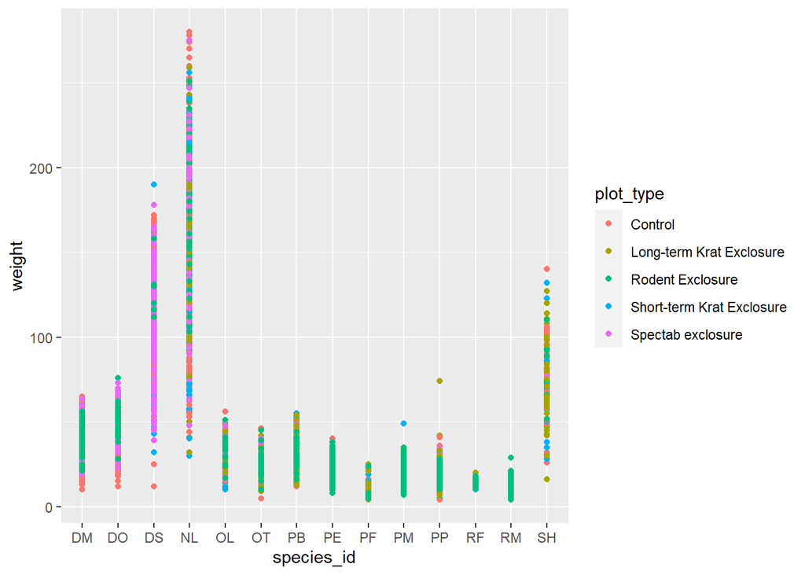

```r
#Create scatter plot
ggplot(surveys_complete, aes(x = species_id, y = weight, color = plot_type)) +
  geom_point()
```

```r
#Export scatter plot
ggsave("Challenge1.jpg", width = 8)
```

# Boxplots

We can use boxplots to visualize the distribution of weight within each species:

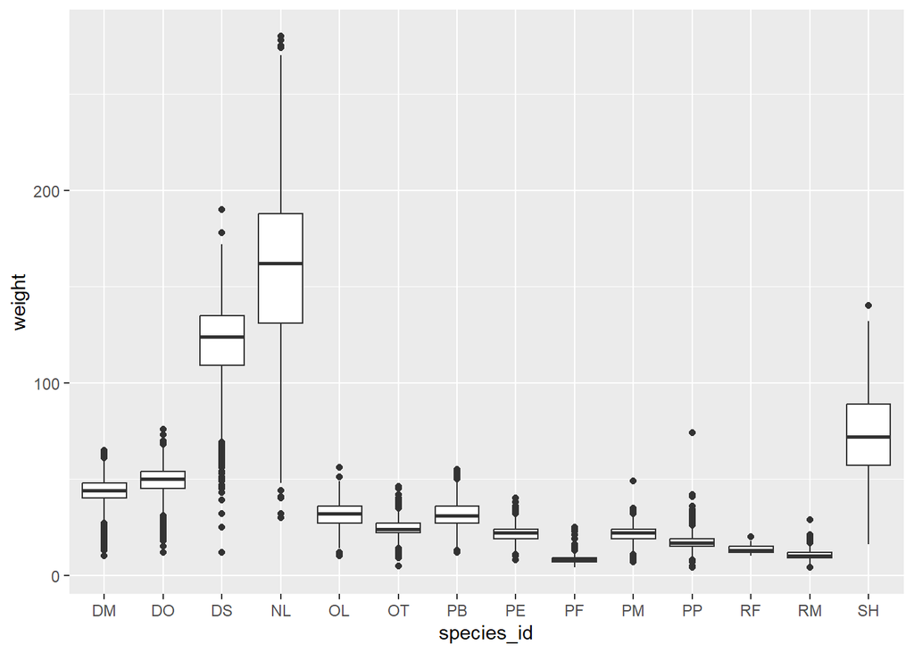

```r
ggplot(data = surveys_complete, mapping = aes(x = species_id, y = weight)) +
    geom_boxplot()
```

The boxplot shows the median (center line), middle 50% of the data distribution (box), and total range (lines), and outliers (points). Outliers are any points outside of 1.5x the interquartile range (size of the box).

By adding points to the boxplot, you can get a better idea of the number of measurements and their distribution:

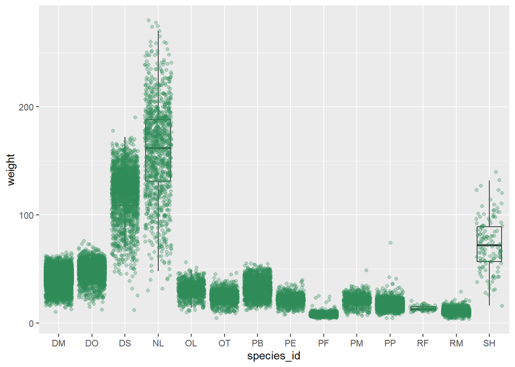

```r
ggplot(data = surveys_complete, mapping = aes(x = species_id, y = weight)) +
    geom_boxplot(alpha = 0) +
    geom_jitter(alpha = 0.3, color = "seagreen")
```

Notice that the boxplot layer is behind the jitter layer. What would you need to change in the code to put the boxplot in front of the points such that it’s not hidden?

**Answer**

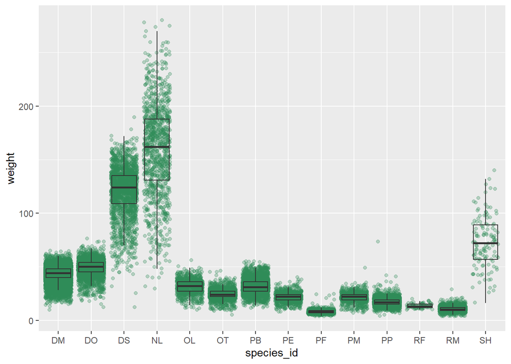

```r
ggplot(data = surveys_complete, mapping = aes(x = species_id, y = weight)) +
  geom_jitter(alpha = 0.3, color = "seagreen") +
  geom_boxplot(alpha = 0)
```

## Challenge 2

> Boxplots are useful summaries, but they hide the shape of the distribution. For example, if the distribution is bimodal, we would not see it in a boxplot. An alternative to the boxplot is the violin plot, where the shape (of the density of points) is drawn. Replace the `geom_boxplot()` layer with `geom_violin()`.  
> You can now remove the `geom_jitter()` layer.  
> For many types of data, it is important to consider the scale of the observations. For example, it may be worth changing the scale of the axis to better distribute the observations in the space of the plot. Changing the scale of the axes is done similarly to adding/modifying other components (*i.e.*, by incrementally adding commands). Add the layer `scale_y_log10()` to your plot to change the scale of the weight axis.  
> When you are satisfied with your plot, use the line `ggsave("Challenge2.jpg")` to export your plot.  
> Upload your plot to Challenge 2 on Brightspace.

**Answer**

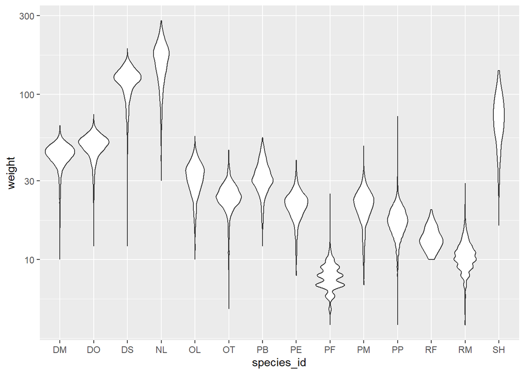

```r
ggplot(surveys_complete, aes(x = species_id, y = weight)) +
  geom_violin() +
  scale_y_log10()
```

```r
ggsave("Challenge2.jpg")
```

## Challenge 3

> So far, we’ve looked at the distribution of weight within species. Make a new plot to explore the distribution of `hindfoot_length` within species.  
> Overlay a boxplot layer on a jitter layer to show actual measurements.  
> Add color to the jitter layer corresponding to the plot from which the sample was taken (`plot_id`).  
> Hint: Check the class for `plot_id`. Within the `color =` argument, add the function `as.factor()` around `plot_id` to change the variable from an integer to a factor. Notice how this changes the way R makes the graph.  
> When you are satisfied with your plot, use the line `ggsave("Challenge3.jpg", width = 8)` to export your plot.  
> Upload your plot to Challenge 3 on Brightspace.

**Answer**

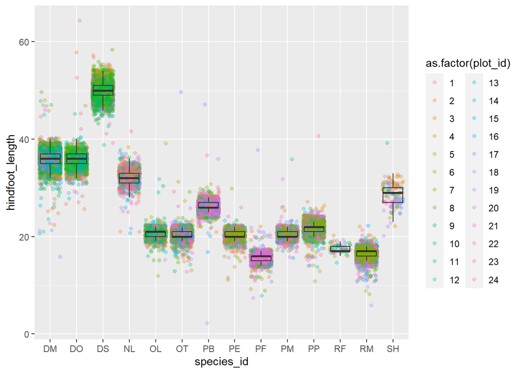

```r
ggplot(surveys_complete, aes(x = species_id, y = hindfoot_length)) +
  geom_jitter(alpha = 0.3, aes(color = as.factor(plot_id))) +
  geom_boxplot(alpha = 0)
```

```r
ggsave("Challenge3.jpg", width = 8)
```

# Plotting time series data

Let’s calculate number of counts per year for each genus. First we need to group the data and count records within each group:

```r
yearly_counts <- surveys_complete %>%
  count(year, genus)
```

Time series data can be visualized as a line plot with years on the x axis and counts on the y axis:

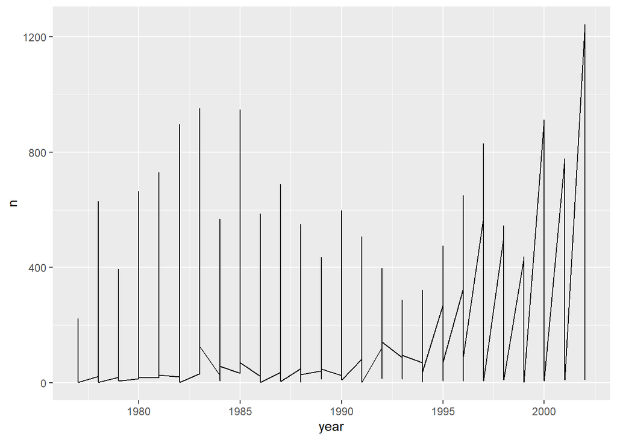

```r
ggplot(data = yearly_counts, mapping = aes(x = year, y = n)) +
     geom_line()
```

Unfortunately, this does not work because we plotted data for all the genera together. We need to tell ggplot to draw a line for each genus by modifying the aesthetic function to include `group = genus`:

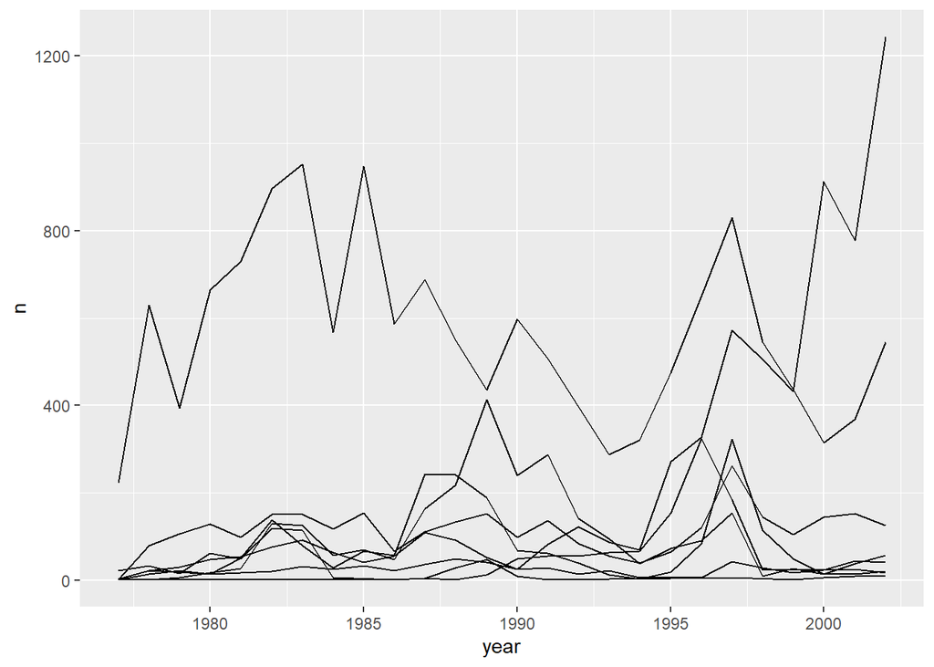

```r
ggplot(data = yearly_counts, mapping = aes(x = year, y = n, group = genus)) +
    geom_line()
```

We will be able to distinguish genera in the plot if we add colors (using `color` also automatically groups the data):

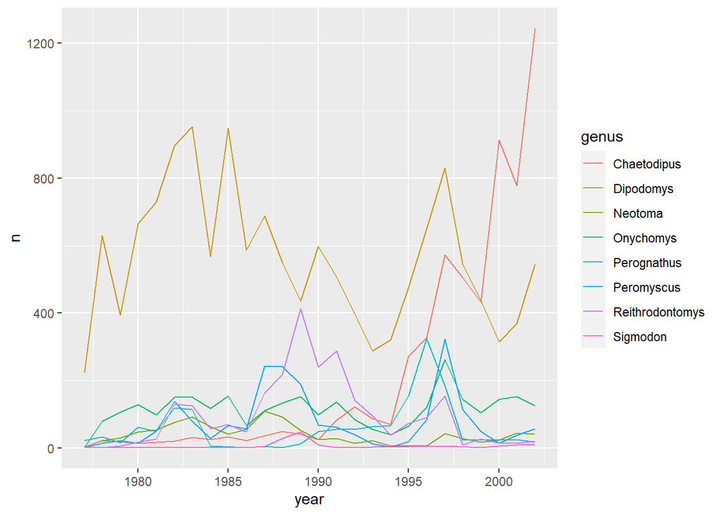

```r
ggplot(data = yearly_counts, mapping = aes(x = year, y = n, color = genus)) +
    geom_line()
```

# Faceting

ggplot2 has a special technique called *faceting* that allows the user to split one plot into multiple plots based on a factor included in the data set.

> There are two type of `facet` functions:
> - `facet_wrap` arranges a one-dimensional sequence of panels to allow them to clearly fit on one page
> - `facet_grid` allows you to form a matrix of rows and columns of panels.

Both geometries allow you to specify faceting variables within `vars()`. For example,  
`facet_wrap(facets = vars(facet_variable))` OR  
`facet_grid(rows = vars(row_variable), cols = vars(col_variable))`.

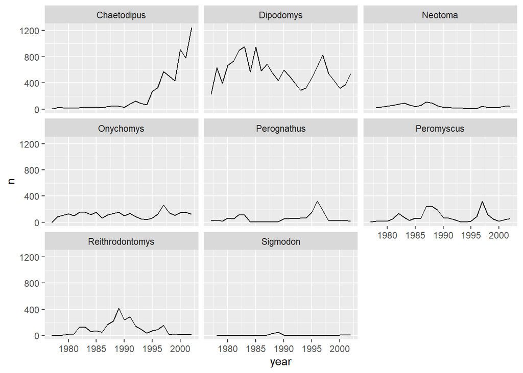

```r
ggplot(data = yearly_counts, mapping = aes(x = year, y = n)) +
    geom_line() +
    facet_wrap(facets = vars(genus))
```

```r
yearly_sex_counts <- surveys_complete %>%
  count(year, genus, sex)
```

We can now make the faceted plot by splitting further by sex using color (within each panel):

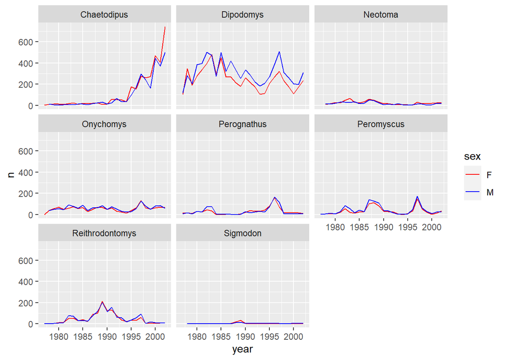

```r
ggplot(data = yearly_sex_counts, mapping = aes(x = year, y = n, color = sex)) +
  geom_line() +
  scale_color_manual(values = c("red", "blue")) +
  facet_wrap(facets =  vars(genus))
```

Note that I also added the layer `scale_color_manual()` to change the colors.

Now let’s use `facet_grid()` to control how panels are organized by both rows and columns:

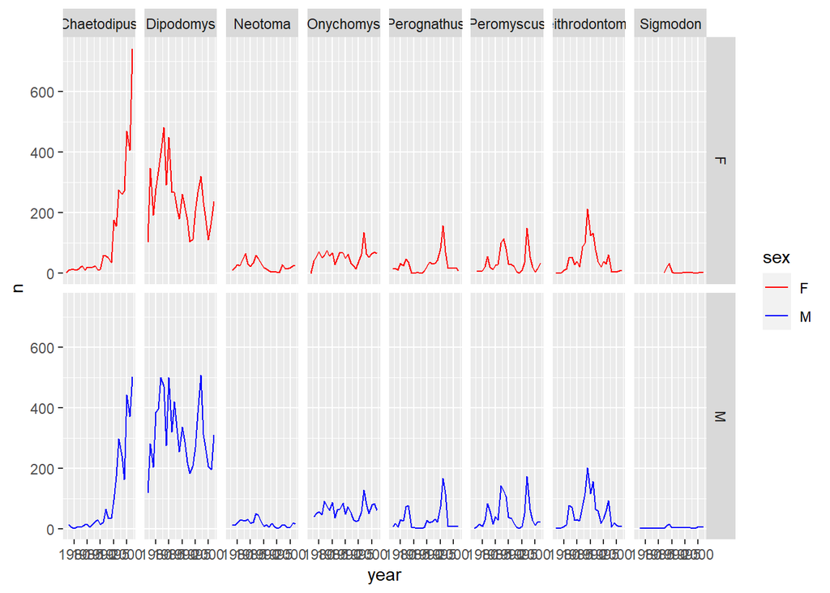

```r
ggplot(data = yearly_sex_counts,
       mapping = aes(x = year, y = n, color = sex)) +
  geom_line() +
  scale_color_manual(values = c("red", "blue")) +
  facet_grid(rows = vars(sex), cols =  vars(genus))
```

You can also organize the panels only by rows (or only by columns):

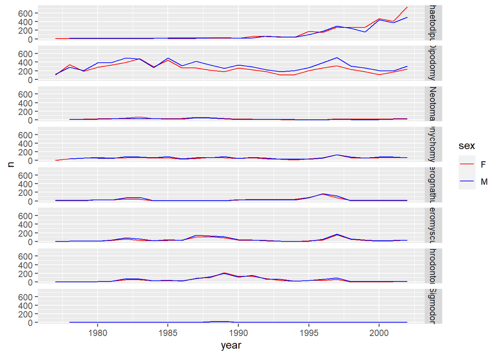

```r
# One column, facet by rows
ggplot(data = yearly_sex_counts,
       mapping = aes(x = year, y = n, color = sex)) +
  geom_line() +
  scale_color_manual(values = c("red", "blue")) +
  facet_grid(rows = vars(genus))
```

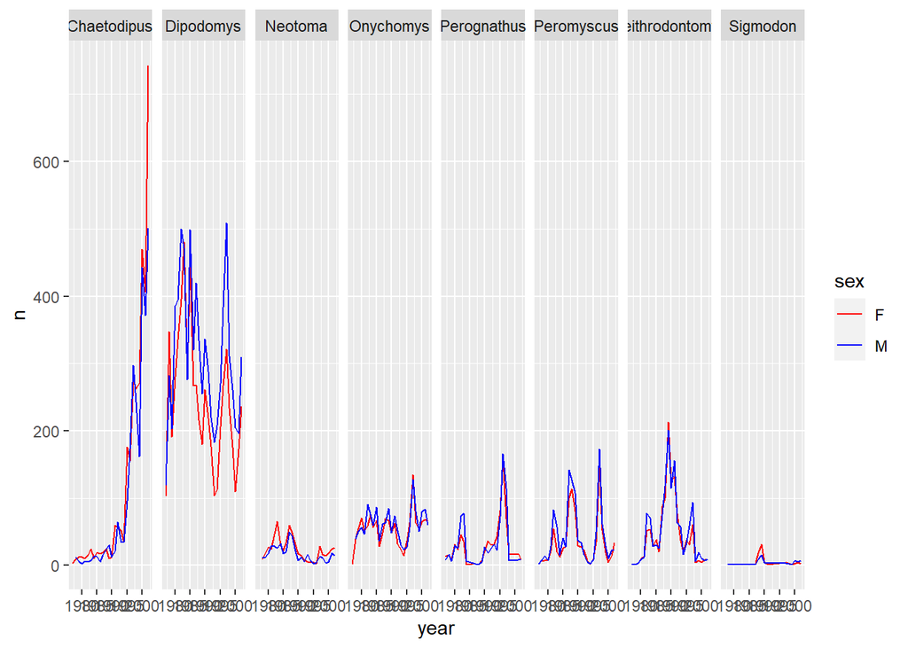

```r
# One row, facet by column
ggplot(data = yearly_sex_counts,
       mapping = aes(x = year, y = n, color = sex)) +
  geom_line() +
  scale_color_manual(values = c("red", "blue")) +
  facet_grid(cols = vars(genus))
```

Note: In earlier versions of `ggplot2` you needed to use an interface using formulas to specify how plots are faceted (and this is still supported in new versions). You may still see this syntax if you look up how to do these things in ggplot. The equivalent syntax is:

```
# facet wrap
facet_wrap(vars(genus))    # new
facet_wrap(~ genus)        # old

# grid on both rows and columns
facet_grid(rows = vars(genus), cols = vars(sex))   # new
facet_grid(genus ~ sex)                            # old

# grid on rows only
facet_grid(rows = vars(genus))   # new
facet_grid(genus ~ .)            # old

# grid on columns only
facet_grid(cols = vars(genus))   # new
facet_grid(. ~ genus)            # old
```

# `ggplot2` themes

Usually plots with white background look more readable when printed. Every single component of a ggplot graph can be customized using the generic `theme()` function, as we will see below. However, there are pre-loaded themes available that change the overall appearance of the graph without much effort.

For example, we can change our previous graph to have a simpler white background using the `theme_bw()` function:

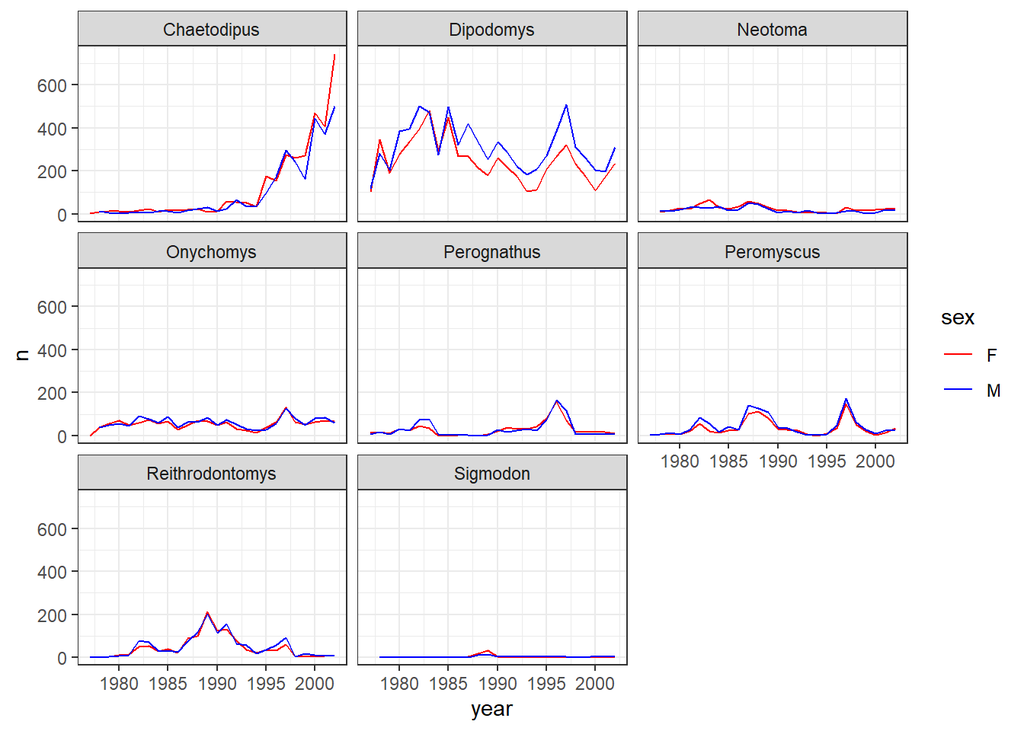

```r
ggplot(data = yearly_sex_counts,
       mapping = aes(x = year, y = n, color = sex)) +
  geom_line() +
  scale_color_manual(values = c("red", "blue")) +
  facet_wrap(vars(genus)) +
  theme_bw()
```

In addition to `theme_bw()`, which changes the plot background to white, `ggplot2` comes with several other themes which can be useful to quickly change the look of your visualization. The complete list of themes is available at https://ggplot2.tidyverse.org/reference/ggtheme.html. `theme_minimal()` and `theme_light()` are popular, and `theme_void()` can be useful as a starting point to create a new hand-crafted theme.

The `ggthemes` package provides a wide variety of options. The `ggplot2` extensions website, https://exts.ggplot2.tidyverse.org/, provides a list of packages that extend the capabilities of `ggplot2`, including additional themes.

```r
#Set theme for plots
theme_set(theme_bw(base_size = 16)+
            theme(panel.grid.major = element_blank(),
                  panel.grid.minor = element_blank(),
                  strip.background = element_blank()))
```

## Challenge 4

> Use what you just learned to create a plot that depicts how the average weight of each species changes through the years.  
> When you are satisfied with your plot, export using `ggsave("Challenge4.jpg", width = 8)`  
> Upload your plot to Challenge 4 on Brightspace.

**Answer**

```r
# Create summary data frame, grouping by year and species id
yearly_weight <- surveys_complete %>%
  group_by(year, species_id) %>%
  summarize(mean_weight = mean(weight, na.rm = T))
```

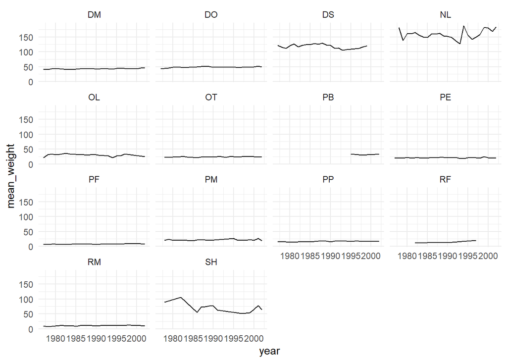

```r
#Plot changes in weight over time, facet by species_id
ggplot(yearly_weight, aes(x = year, y = mean_weight)) +
  geom_line() +
  facet_wrap(vars(species_id)) +
  theme_minimal()
```

```r
ggsave("Challenge4.jpg", width = 8)
```

# Customization

Take a look at the `ggplot2` cheat sheet on Brightspace, and think of ways you could improve the plot.

Now, let’s change the names of axes to something more informative than “year” and “n.”

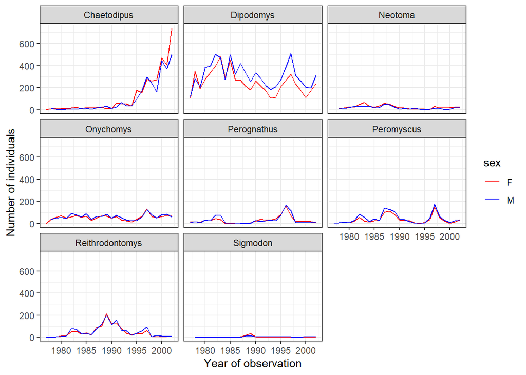

```r
ggplot(data = yearly_sex_counts, mapping = aes(x = year, y = n, color = sex)) +
  geom_line() +
  scale_color_manual(values = c("red", "blue")) +
  facet_wrap(vars(genus)) +
  labs(x = "Year of observation",
       y = "Number of individuals") +
  theme_bw()
```

(Note that it is also possible to change the fonts of your plots. If you are on Windows, you may have to install the `extrafont` package, and follow the instructions included in the README for this package.)

After our manipulations, you may notice that the values on the x-axis are still not properly readable. Let’s change the orientation of the labels and adjust them vertically and horizontally so they don’t overlap. You can use a 90-degree angle, or experiment to find the appropriate angle for diagonally oriented labels:

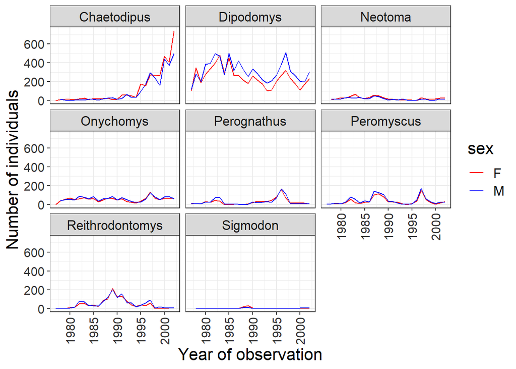

```r
ggplot(data = yearly_sex_counts, mapping = aes(x = year, y = n, color = sex)) +
  geom_line() +
  scale_color_manual(values = c("red", "blue")) +
  facet_wrap(vars(genus)) +
  labs(x = "Year of observation",
       y = "Number of individuals") +
  theme_bw() +
  theme(axis.text.x = element_text(color = "grey20", size = 12, angle = 90,
                                   hjust = 0.5, vjust = 0.5),
        axis.text.y = element_text(color = "grey20", size = 12),
        text = element_text(size = 16))
```

If you like the changes you created, you can save them as an object to be able to easily apply them to other plots you may create:

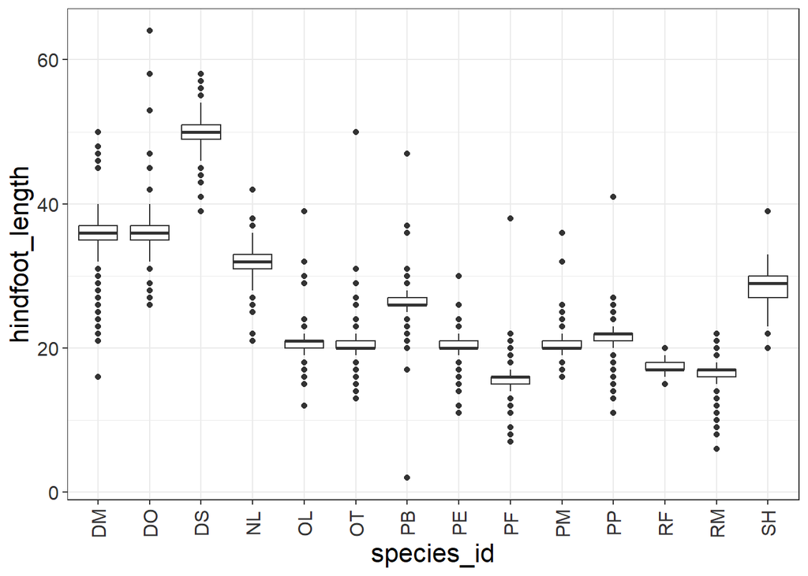

```r
# define custom theme
grey_theme <- theme(axis.text.x = element_text(colour = "grey20", size = 12, angle = 90,
                                               hjust = 0.5, vjust = 0.5),
                    axis.text.y = element_text(colour = "grey20", size = 12),
                    text = element_text(size = 16))

# Create a boxplot with new theme
ggplot(surveys_complete, aes(x = species_id, y = hindfoot_length)) +
  geom_boxplot() +
  theme_bw() +
  grey_theme
```

## Challenge 5

> With all of this information in hand, please take another five minutes to either improve one of the plots generated in this exercise or create a beautiful graph of your own. Use the **ggplot2** cheat sheet for inspiration. Here are some ideas:

> * See if you can change the thickness of the lines.  
> * Can you find a way to change the name of the legend? What about the labels in the legend?  
> * Try using a different color palette (check out http://www.cookbook-r.com/Graphs/Colors_(ggplot2)/ and https://coolors.co/).

> When you are satisfied with your plot, use `ggsave()` to export it.  
> Adjust the height and width arguments in `ggsave()` until you are happy with your final plot.  
> Upload your final plot to Challenge 5 on Brightspace.

# Exporting plots

Throughout this exercise we have used `ggsave()` to export plots. The Export tab in the Plot pane in RStudio will save your plots at low resolution, which will not be accepted by many journals and will not scale well for posters.

Instead, you should use the `ggsave()` function, which allows you to easily change the dimensions and resolution of your plot by adjusting the appropriate arguments (`width`, `height`, and `dpi`). You can also choose the type of file you wish to export by changing the file extension. For example, you may wish to save your file as a .png if you wish it to have a transparent background. Some journals may require you to submit images as a .tif.